# R: Self Learn Basics Part Deaux

Tobin Turner

2/10/2021

# 1 Let’s learn us some MORE R

## 1.1 Attaching to objects

R includes a number of datasets that it is convenient to use for examples. You can get a description of what’s available by typing

```r
data()
```

To access any of these datasets, you then type data(dataset) where dataset is the name of the dataset you wish to access. For example,

```r
data(trees)
trees[1:5,]
```

```
##   Girth Height Volume
## 1   8.3     70   10.3
## 2   8.6     65   10.3
## 3   8.8     63   10.2
## 4  10.5     72   16.4
## 5  10.7     81   18.8
```

gives us the first 5 rows of these data, and we can now see that the columns represent measurements of girth, height and volume of trees (actually cherry trees: see help(trees)) respectively. Now, if we want to work on the columns of these data, we can use the subscripting technique explained above: for example, trees[,2] gives all of the heights. This is a bit tedious however, and it would be easier if we could refer to the heights more explicitly. We can achieve this by attaching to the trees dataset:

```r
attach(trees)
```

Effectively, this makes the contents of trees a directory, and if we type the name of an object, R will look inside this directory to find it. Since Height is the name of one of the columns of trees, R now recognises this object when we type the name. Hence, for example,

```r
mean(Height)
```

```
## [1] 76
```

```r
mean(trees[,2])
```

```
## [1] 76
```

are synonymous, while it is easier to remember exactly what calculation is being performed by the first of these expressions. In actual fact, trees is an object called a dataframe, essentially a matrix with named columns (though a dataframe, unlike a matrix, may also include non-numerical variables, such as character names). Because of this, there is another equivalent syntax to extract, for example, the vector of heights:

```r
trees$Height
```

```
##  [1] 70 65 63 72 81 83 66 75 80 75 79 76 76 69 75 74 85 86 71 64 78 80 74 72 77
## [26] 81 82 80 80 80 87
```

which can also be used without having first attached to the dataset.

## 1.2 Exercises

1. Attach to the dataset quakes and produce a statistical summary of the variables depth and mag.
2. Attach to the dataset mtcars and find the mean weight and mean fuel consumption for vehicles in the dataset (type help(mtcars) for a description of the variables available).

## 1.3 The apply function

It is possible to write loops in R, but they are best avoided whenever possible. A common situation is where we want to apply the same function to every row or column of a matrix. For example, we may want to find the mean value of each variable in the trees dataset. Obviously, we could operate on each column separately but this can be tedious, especially if there are many columns. The function apply simplifies things. It is easiest understood by example:

```r
apply(trees,2,mean)
```

```
##    Girth   Height   Volume
## 13.24839 76.00000 30.17097
```

has the effect of calculating the mean of each column (dimension 2) of trees. We’d have used a 1 instead of a 2 if we wanted the mean of every row. Any function can be applied in this way, though if optional arguments to the function are required these need to be speci ed as well - see help(apply) for further details.

## 1.4 Exercises

1. Repeat the analyses of the datasets quakes and mtcars using the function apply to simplify the calculations.
2. If y =

```
##      [,1] [,2] [,3]
## [1,]    1    4    1
## [2,]    0    2    1
```

what is the result of apply(y[,2:3],1,mean)? Check your answer in R.

## 1.5 Graphics

R has many facilities for producing high quality graphics. A useful facility before beginning is to divide a page into smaller pieces so that more than one figure can be displayed. For example:

```r
par(mfrow=c(2,2))
```

creates a window of graphics with 2 rows and 2 columns. With this choice the windows are filled up row-wise. Use mfcol instead of mfrow to fill up column-wise. The function par is a general function for setting graphical parameters. There are many options: see help(par).

So, for example

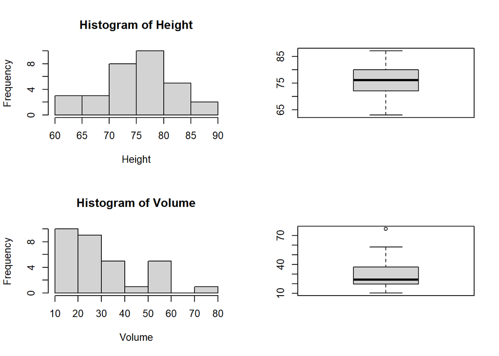

Figure 1: Tree heights and volumes

```r
par(mfrow=c(2,2))
hist(Height)
boxplot(Height)
hist(Volume)
boxplot(Volume)
```

```r
par(mfrow=c(1,1))
```

produces Figure 1. Note the final use of par to return the graphics window to standard size.

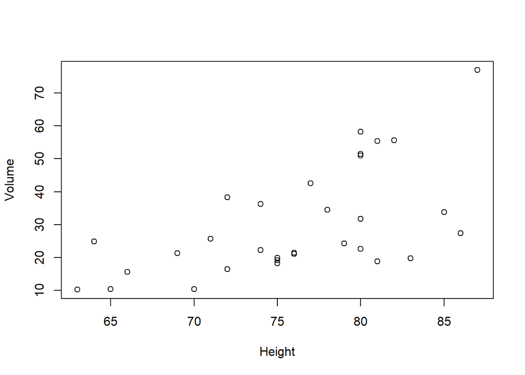

Figure 2: Scatterplot of tree heights and volumes

```r
plot(Height,Volume)
```

We can also plot one variable against another using the function plot:

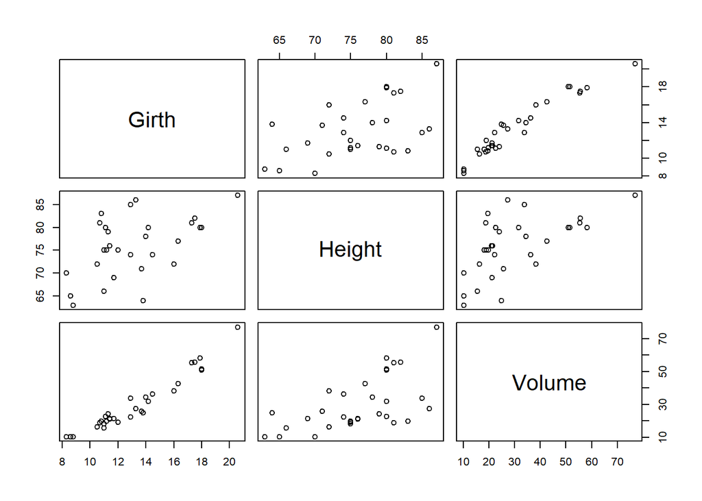

Figure 3: Scatterplot matrix for tree data

```r
pairs(trees)
```

See Figure 3. Like many other functions plot is object-speci c: its behaviour depends on the object to which it is applied. For example, if the object is a matrix, plot is identical to pairs: try plot(trees). For some other possibilities try:

```r
data(nhtemp)
plot(nhtemp)

data(faithful)
plot(faithful)

data(HairEyeColor)
plot(HairEyeColor)
```

There are also many optional arguments in most plotting functions that can be used to control colours, plotting characters, axis labels, titles etc. The functions points and lines are useful for adding points and lines respectively to a current graph. The function abline is useful for adding a line with specified intercept and slope. To print a graph, point the cursor over the graphics window and press the right button on the mouse. This should open up a menu which includes `print’ as an option. You also have the option to save the figure in various formats, for example as a postscript file, for storage and later use.

## 1.6 Exercises

1. Use > x<-rnorm(100)

or something similar, to generate some data. Produce a figure showing a histogram and boxplot of the data. Modify the axis names and title of the plot in an appropriate way.

2. Type the following

```r
x<- (-10):10
n<-length(x)
y<-rnorm(n,x,4)
plot(x,y)
abline(0,1)
```

Try to understand the effect of each command and the graph that is produced.

3. Type the following:

```r
data(nhtemp)
plot(nhtemp)
```

This produces a time series plot of measurements of annual mean temperatures in New Hampshire, U.S.A.

4. The previous example illustrated that plot acts differently on objects of different types - the object nhtemp has the special class time series. More generally, we may have the data of yearly observations in a vector, but need to build the time series plot for ourselves. We can mimic this situation by typing

`temp<-as.vector(nhtemp)`

which creates a vector temp that contains only the annual temperatures. We can produce something similar to the time series plot by typing `plot(1912:1971,temp)` but this plots points rather than lines. To join the data via lines we would use `plot(1912:1971,temp,type='l')` instead. To get points and lines, use `type='b'` instead.